# TuktuTools: Part II - Data Summaries

Workshop Materials: NACW 2023 - Anchorage

Eliezer Gurarie and Ophélie Couriot

May 8, 2023

The `TuktuTools` packages offers a range of functions allowing to easily summarize data and estimate movement rate and range distributions. Some examples are below. They are based off the “prepped” caribou data from Part I, which clips the movement to a short period for the analysis of parturitions.

```r
require(TuktuTools)
data(caribou)
caribou_sf <- st_as_sf(caribou,
                       coords = c("Lon","Lat"), crs = 4326)
caribou_prepped <- prepData(caribou, start = "05-19", end = "07-07") %>%
  st_as_sf(coords = c("Lon","Lat"), crs = 4326)
```

```
## Period clipped to 05-19 - 07-07
## Number of excluded individuals-years: 2
```

# Get the daily mean location

`getDailyMean()` takes any large movement dataset and returns the daily mean locations for each individual for each day for each year of observations.

Let’s calculate the daily mean locations for individuals during the calving period.

```r
caribou_daily_mean <- getDailyMean(caribou_prepped)
caribou_daily_mean
```

```
## Simple feature collection with 535 features and 7 fields
## Geometry type: POINT
## Dimension:     XY
## Bounding box:  xmin: -37398.69 ymin: 7070335 xmax: 454152 ymax: 7344976
## Geodetic CRS:  WGS 84
## First 10 features:
##        ID Year yday         X        Y sex                Time
## 1  Dancer 2002  139 -130.5903 64.93708   f 2002-05-19 08:00:00
## 2  Dancer 2002  140 -130.4412 65.17436   f 2002-05-20 08:00:00
## 3  Dancer 2002  141 -130.2851 65.35544   f 2002-05-21 08:00:00
## 4  Dancer 2002  142 -130.0343 65.54760   f 2002-05-22 08:00:00
## 5  Dancer 2002  143 -129.6419 65.74962   f 2002-05-23 08:00:00
## 6  Dancer 2002  144 -129.4325 65.92092   f 2002-05-24 08:00:00
## 7  Dancer 2002  145 -129.1612 66.02657   f 2002-05-25 08:00:00
## 8  Dancer 2002  146 -129.0105 66.01968   f 2002-05-26 08:00:00
## 9  Dancer 2002  147 -129.2951 66.01536   f 2002-05-27 08:00:00
## 10 Dancer 2002  148 -129.5554 66.02423   f 2002-05-28 08:00:00
##                    geometry
## 1    POINT (141896 7222972)
## 2    POINT (152022 7248435)
## 3  POINT (161623.4 7267659)
## 4  POINT (175623.2 7287645)
## 5  POINT (196039.9 7308092)
## 6  POINT (207557.8 7326106)
## 7  POINT (221013.1 7336598)
## 8  POINT (227746.6 7335168)
## 9  POINT (214846.9 7335958)
## 10 POINT (203188.8 7338148)
```

This function becomes handy when we are dealing with very large dataset, to homogenize data, by having one location per day for each individual, and do further analyses not requiring a fine fix rate.

## Get the daily movement rates

The package contains a function which is calculating the movement rate between successive locations for each individual: `getSpeed`.

Calculating the movement rate between successive daily locations. Note that this function calculate movement rate for each individual separately, but if individuals are monitored several years with a break in between (as in this case, since we considered only the calving period), it is essential to apply this function to each individual and year separately!

```r
daily_mr <- caribou_daily_mean %>% mutate(ID_year = paste(ID, Year)) %>%
  getSpeed(id.col = "ID_year")
head(daily_mr)
```

```
## Simple feature collection with 6 features and 15 fields
## Geometry type: POINT
## Dimension:     XY
## Bounding box:  xmin: 241878.2 ymin: 7316549 xmax: 250584.8 ymax: 7328800
## Geodetic CRS:  WGS 84
##      ID Year yday         X        Y sex                Time    ID_year
## 1 Comet 2006  139 -128.4736 65.87219   f 2006-05-19 08:00:40 Comet 2006
## 2 Comet 2006  140 -128.6367 65.95427   f 2006-05-20 08:00:00 Comet 2006
## 3 Comet 2006  141 -128.6444 65.97626   f 2006-05-21 08:00:00 Comet 2006
## 4 Comet 2006  142 -128.6755 65.91915   f 2006-05-22 08:00:00 Comet 2006
## 5 Comet 2006  143 -128.5542 65.92500   f 2006-05-23 08:00:20 Comet 2006
## 6 Comet 2006  144 -128.5148 65.92819   f 2006-05-24 08:00:00 Comet 2006
##          x       y               z       dt        sl    dhours     speed
## 1 250584.8 7316549 250585+7316549i       NA        NA   0.00000        NA
## 2 243987.1 7326326 243987+7326326i 23.98889 11794.837  23.98889 491.67919
## 3 243859.4 7328800 243859+7328800i 24.00000  2477.436  47.98889 103.22652
## 4 241878.2 7322583 241878+7322583i 24.00000  6525.256  71.98889 271.88566
## 5 247440.4 7322739 247440+7322739i 24.00556  5564.371  95.99444 231.79513
## 6 249257.8 7322935 249258+7322935i 23.99444  1828.024 119.98889  76.18532
##                   geometry
## 1 POINT (250584.8 7316549)
## 2 POINT (243987.1 7326326)
## 3 POINT (243859.4 7328800)
## 4 POINT (241878.2 7322583)
## 5 POINT (247440.4 7322739)
## 6 POINT (249257.8 7322935)
```

We can visualize the movement rate of each individual through time. To have all the individuals on the same figure, we add a column `doy` (i.e, day of year). We also need to create a column for each ID-Year, as some individuals have been monitored several years.

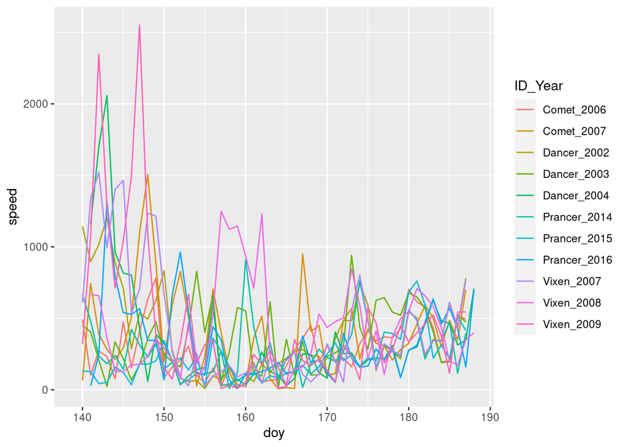

```r
daily_mr <- daily_mr %>% mutate(doy = yday(Time), ID_Year = as.factor(paste(ID, Year, sep = "_")))
ggplot(data = daily_mr, aes(x = doy, y = speed, group = ID_Year, colour = ID_Year)) + geom_line()
```

## Utilization distributions

## Kernel Densities

In the `TuktuTools` package, we added a function that allows to easily compute kernel utilization distributions, in one line of code: `getKernelUD`. This function uses the function `kernelUD` from the `adehabitatHR` package, and thus has the same parameters found in the `kernelUD` function.

```r
individuals_kernel <- caribou_daily_mean %>%
  st_as_sf(coords=c("x", "y"), crs = 32610) %>%
  ddply(c("ID","Year"), getKernelUD, extent = 10) %>%
  st_as_sf(crs = 32610)
head(individuals_kernel)
```

```
## Simple feature collection with 6 features and 4 fields
## Geometry type: POLYGON
## Dimension:     XY
## Bounding box:  xmin: 51181.27 ymin: 7125049 xmax: 419304.2 ymax: 7385712
## Projected CRS: WGS 84 / UTM zone 10N
##        ID Year        id        area                       geometry
## 1  Dancer 2002 homerange 12188602525 POLYGON ((113142.5 7241814,...
## 2  Dancer 2003 homerange 48483706527 POLYGON ((79139.69 7205536,...
## 3  Dancer 2004 homerange 21657374195 POLYGON ((107241.3 7233415,...
## 4 Prancer 2014 homerange 11318075672 POLYGON ((106989.8 7258670,...
## 5 Prancer 2015 homerange 11568424749 POLYGON ((96700.08 7229964,...
## 6 Prancer 2016 homerange 29417123198 POLYGON ((99316.73 7241306,...
```

```r
# visualize
mapview::mapview(individuals_kernel, zcol = "ID")
```

[interactive chart not shown]

## Local Convex Hulls

We also added the `getLoCoH` function, which allows to compute Local Convex Hull (LoCoH). Read more about these here: http://tlocoh.r-forge.r-project.org/. In short, these are known to perform better than parametric kernel methods, in the context of estimating the size of home ranges and delineating geological and ecological features in home ranges.

The LoCoH method is both a generalization of the minimum convex polygon (MCP) method and essentially a non-parametric kernel method. LoCoH applies the MCP construction to a subset of data localized in space, and the local convex polygon (i.e. local hull) is constructed using a specific number of nearest neighbors (nn) of each data point, thereby producing a set of nonparametric kernels whose union is the UD.

One advantage of using LoCoH is that this method allows to consider avoided areas (or holes) in ranges.

One complication of using this method is that you need to install the `tlocoh` package which is not on CRAN, but on another repository.

To install T-LoCoH, type one of the following commands below at the R console. If you get stuck, see the steps for manual installation.

```r
# Windows:
install.packages("tlocoh", dependencies=TRUE, repos=c("http://R-Forge.R-project.org", "http://cran.cnr.berkeley.edu"))
require(tlocoh)
```

```r
# Mac / LINUX:
install.packages("tlocoh", dependencies=TRUE, repos=c("http://R-Forge.R-project.org", "http://cran.cnr.berkeley.edu"), type="source")
require(tlocoh)
```

The following code will estimate the local convex hull estimate range of animals of day of year.

```r
individuals_locoh <- caribou_sf %>%
  ddply(c("ID","Year"), getLoCoH, nn = 30)
```

[output not shown]

[output not shown]

[output not shown]

[output not shown]

[output not shown]

[output not shown]

[output not shown]

[output not shown]

[output not shown]

[output not shown]

[output not shown]

[output not shown]

[output not shown]

```r
#head(individuals_locoh)

# visualize
mapview::mapview(individuals_locoh %>% st_as_sf, zcol = "ID")
```

[interactive chart not shown]

```r
individuals_locoh2 <- caribou_daily_mean %>% st_as_sf(coords=c("x", "y"), crs = 32610) %>%
  ddply(c("ID","Year"), getLoCoH, nn = 30) %>% st_as_sf(crs = 32610)
```

[output not shown]

[output not shown]

[output not shown]

[output not shown]

[output not shown]

[output not shown]

[output not shown]

[output not shown]

[output not shown]

[output not shown]

[output not shown]

```r
head(individuals_locoh2)
```

```
## Simple feature collection with 6 features and 9 fields
## Geometry type: POLYGON
## Dimension:     XY
## Bounding box:  xmin: 101054.8 ymin: 7199165 xmax: 373624 ymax: 7342216
## Projected CRS: WGS 84 / UTM zone 10N
##        ID Year iso.level       area edge.len nep       ptp     hm.val num.hulls
## 1  Dancer 2002      0.95 3435319719 287122.1  48 0.9795918 2228207540        33
## 2  Dancer 2003      0.95 7696562183 590162.2  49 1.0000000 4976889697        38
## 3  Dancer 2004      0.95 5795861390 390309.7  46 0.9583333 4496207575        41
## 4 Prancer 2014      0.95 3705011389 274058.1  47 0.9591837 2327582610        31
## 5 Prancer 2015      0.95 2847761237 290603.4  48 0.9795918 2545937038        42
## 6 Prancer 2016      0.95 8546771254 525972.7  48 1.0000000 6014727135        42
##                         geometry
## 1 POLYGON ((210809.3 7283850,...
## 2 POLYGON ((343640.7 7311865,...
## 3 POLYGON ((219927.8 7328265,...
## 4 POLYGON ((186191.4 7338714,...
## 5 POLYGON ((220916.8 7311578,...
## 6 POLYGON ((233972.4 7327925,...
```

```r
#  visualize
mapview::mapview(individuals_locoh2, zcol = "ID")
```

[interactive chart not shown]

We can see that the more nearest neighbors, the less sensitive the method to areas that are actively avoided.